### Lab 6 In-class exercises solution

1. Calculate the market share of each brand in its product category. Create a data frame with top three brands in each category.

```r
library(tidyverse)
prodsales <- read_csv("../prodsales.csv")
brands <- prodsales %>% group_by(commodity, brand) %>%
  summarize(sales=sum(tot_sales)) %>%
  arrange(commodity, -sales)
brands <- brands %>% group_by(commodity) %>% mutate(tot_cat_sale=sum(sales), rank=rank(-sales))
brands$share <- brands$sales/brands$tot_cat_sale
brands <- filter(brands, rank<4)
brands
```

```
## # A tibble: 12 x 6
## # Groups: commodity [4]
##    commodity     brand             sales tot_cat_sale  rank  share
##    <chr>         <chr>             <dbl>        <dbl> <dbl>  <dbl>
##  1 pancake mixes Aunt Jemima      206709       511840  1.00 0.404
##  2 pancake mixes Hungry Jack      111438       511840  2.00 0.218
##  3 pancake mixes Private Label     73620       511840  3.00 0.144
##  4 pasta         Private Label    995288      2852544  1.00 0.349
##  5 pasta         Barilla          433894      2852544  2.00 0.152
##  6 pasta         Creamette        271595      2852544  3.00 0.0952
##  7 pasta sauce   Ragu            1500841      4025199  1.00 0.373
##  8 pasta sauce   Prego            799949      4025199  2.00 0.199
##  9 pasta sauce   Classico         438187      4025199  3.00 0.109
## 10 syrups        Aunt Jemima      359669      1741337  1.00 0.207
## 11 syrups        Private Label    352953      1741337  2.00 0.203
## 12 syrups        Mrs Butterworth  159165      1741337  3.00 0.0914
```

2. Suppose we wanted to predict the outcome of the games in our NHL data set. What variables would you want to use?
3. (`cumsum()` function) Suppose you wanted to create a measure of the opposing teams success so far in the season. Suppose further that you wanted to measure that success by counting the number of games won so far in the season. Create a variable that calculates that number for each team (home and visiting) for each game. The code below is to get you started. Can you tell what it does?

```r
nhl <- read_csv("../NHLseason2016.csv")
#create data with home games for each team
home_games <- nhl %>%
              rename(team=Home, goals_for=goals_home, goals_against=goals_visit) %>%
              select(Date, team, goals_for, goals_against)
#create data with away games for each team
away_games <- nhl %>%
              rename(team=Visitor, goals_for=goals_visit, goals_against=goals_home) %>%
              select(Date, team, goals_for, goals_against)
#put home_games and away_games together
#each game is in two rows: one as the home game, one as the away game
games <- bind_rows(home_games, away_games)
#create win variable
games$win <- ifelse(games$goals_for-games$goals_against>0,1,0)
games <- arrange(games, team, Date)
```

Now let’s create the cumulative wins variable:

```r
games <- games %>% group_by(team) %>% mutate(cumwins = cumsum(win))
head(games, n=8)
```

```
## # A tibble: 8 x 6
## # Groups: team [1]
##   Date       team          goals_for goals_against   win cumwins
##   <date>     <chr>             <int>         <int> <dbl>   <dbl>
## 1 2015-10-10 Anaheim Ducks         0             2  0       0
## 2 2015-10-12 Anaheim Ducks         1             2  0       0
## 3 2015-10-14 Anaheim Ducks         0             4  0       0
## 4 2015-10-16 Anaheim Ducks         0             3  0       0
## 5 2015-10-18 Anaheim Ducks         4             1  1.00    1.00
## 6 2015-10-22 Anaheim Ducks         1             5  0       1.00
## 7 2015-10-24 Anaheim Ducks         0             3  0       1.00
## 8 2015-10-26 Anaheim Ducks         0             1  0       1.00
```

```r
#let's shift cumwins by one game for each team so that
#cumwins has the number of wins BEFORE the start of the game
games <- games %>% group_by(team) %>% mutate(cumwins_l = lag(cumwins))
#replace NAs with zero (the number of wins before the first game is, after all, zero)
games$cumwins_l <- ifelse(is.na(games$cumwins_l),0,games$cumwins_l)
head(games, n=8)
```

```
## # A tibble: 8 x 7
## # Groups: team [1]
##   Date       team          goals_for goals_against   win cumwins cumwins_l
##   <date>     <chr>             <int>         <int> <dbl>   <dbl>     <dbl>
## 1 2015-10-10 Anaheim Ducks         0             2  0       0         0
## 2 2015-10-12 Anaheim Ducks         1             2  0       0         0
## 3 2015-10-14 Anaheim Ducks         0             4  0       0         0
## 4 2015-10-16 Anaheim Ducks         0             3  0       0         0
## 5 2015-10-18 Anaheim Ducks         4             1  1.00    1.00      0
## 6 2015-10-22 Anaheim Ducks         1             5  0       1.00      1.00
## 7 2015-10-24 Anaheim Ducks         0             3  0       1.00      1.00
## 8 2015-10-26 Anaheim Ducks         0             1  0       1.00      1.00
```

Let’s not stop here. Let’s join the lagged cumulative wins back into the `nhl` data so that we can see if the “record so far”, as measured by lagged cumulative wins, predicts game outcomes.

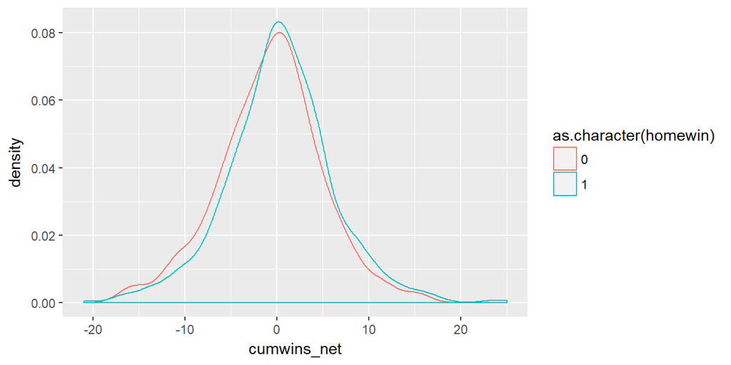

```r
# rearrange games so that we can see opposing teams and their record so far
games_home2 <- select(games, cumwins_l, Date, team) %>% rename(Home=team, cumwins_home=cumwins_l)
games_away2 <- select(games, cumwins_l, Date, team) %>% rename(Visitor=team,cumwins_visit=cumwins_l)

#join the cumwins with nhl
nhl2 <- inner_join(nhl, games_home2, by=c("Home", "Date"))
nhl2 <- inner_join(nhl2, games_away2, by=c("Visitor", "Date"))

#create the difference between home and visiting teams cumulative wins
nhl2$cumwins_net <- nhl2$cumwins_home-nhl2$cumwins_visit
nhl2$score <- nhl2$goals_home-nhl2$goals_visit
nhl2$homewin <- ifelse(nhl2$goals_home>nhl2$goals_visit,1,0)

ggplot(nhl2) + geom_density(aes(x=cumwins_net,color=as.character(homewin)))
```

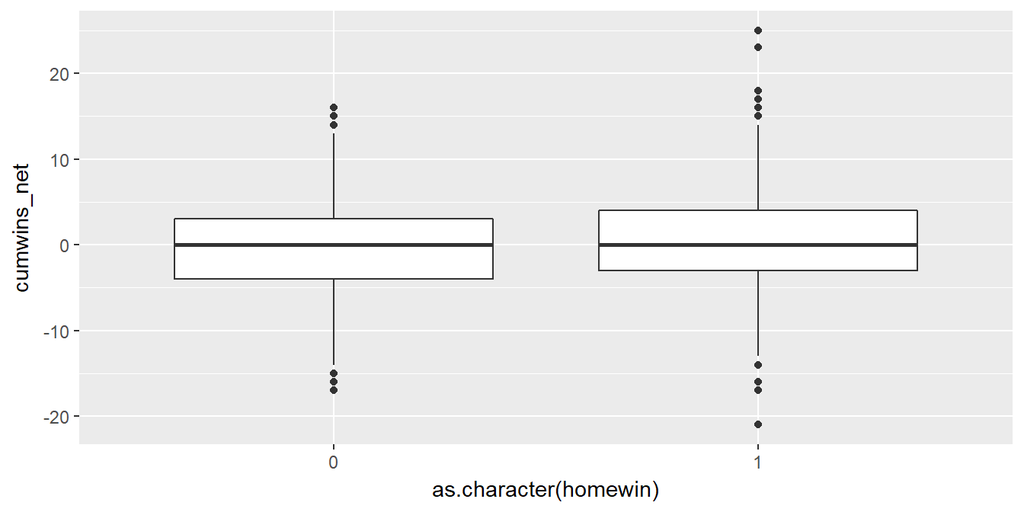

```r
ggplot(nhl2) + geom_boxplot(aes(x=as.character(homewin),y=cumwins_net))
```

```r
t.test(nhl2$cumwins_net ~ as.factor(nhl2$homewin))
```

```
##
##  Welch Two Sample t-test
##
## data:  nhl2$cumwins_net by as.factor(nhl2$homewin)
## t = -3.1182, df = 1218.9, p-value = 0.001862
## alternative hypothesis: true difference in means is not equal to 0
## 95 percent confidence interval:
##  -1.6629340 -0.3785008
## sample estimates:
## mean in group 0 mean in group 1
##      -0.7012090       0.3195084
```

```r
write.csv(nhl2, "nhl with cum wins.csv", row.names = FALSE)
```